# Nguyen_Tyler_Final_Exam

Stats 20 Spring 2022

6/8/2022

```r
load("final_data.RData")
load("Store.RData")
data <- merge(yr2016, yr2018, all = TRUE)
data2 <- merge(data, yr2020, all = TRUE)
finalIowa <- merge(data2, store, by.x = "Store Number")
```

Firstly, I have to load the data into environment and merge data sets together

# 1

## A

```r
nrow(finalIowa)
```

```
## [1] 11882
```

```r
ncol(finalIowa)
```

```
## [1] 16
```

The data set has 11882 rows and 16 columns. The name of the columns are:

```r
names(finalIowa)
```

```
##  [1] "Store Number"          "Invoice/Item Number"   "Date"
##  [4] "Category"              "Vendor Number"         "Item Number"
##  [7] "State Bottle Retail"   "Bottles Sold"          "Sale (Dollars)"
## [10] "Volume Sold (Liters)"  "Volume Sold (Gallons)" "Store Name"
## [13] "Address"               "City"                  "Zip Code"
## [16] "County"
```

Now, I look at what type of variables I am working with.

```r
sapply(finalIowa, class) |> table()
```

```
##
## character      Date
##        15         1
```

I know by the names of the variables that I need to convert some of these character variables to numeric. I look at the first few rows of data to know which ones to convert

```r
head(finalIowa)
```

```
##   Store Number Invoice/Item Number       Date Category Vendor Number
## 1         2106     INV-11726900055 2018-04-26  1081600           421
## 2         2106     INV-12519400024 2018-06-07  1031200           434
## 3         2106        S33152600063 2016-06-30  1081200           260
## 4         2106        S32413900065 2016-05-19  1081200           260
## 5         2106     INV-01363700059 2016-11-03  1081300           065
## 6         2106     INV-02026600060 2016-12-08  1081300           434
##   Item Number State Bottle Retail Bottles Sold Sale (Dollars)
## 1       64866              $13.50           24        $324.00
## 2       35179              $10.50           12        $126.00
## 3       68037              $24.75           12        $297.00
## 4       74090              $25.50           12        $306.00
## 5       85526               $7.88           24        $189.12
## 6       79336               $7.50           12         $85.56
##   Volume Sold (Liters) Volume Sold (Gallons)                  Store Name
## 1                   18                  4.76 Hillstreet News and Tobacco
## 2                    9                  2.38 Hillstreet News and Tobacco
## 3                   12                  3.17 Hillstreet News and Tobacco
## 4                    9                  2.38 Hillstreet News and Tobacco
## 5                   18                  4.76 Hillstreet News and Tobacco
## 6                    9                  2.38 Hillstreet News and Tobacco
##        Address        City Zip Code     County
## 1 2217 College Cedar Falls    50613 BLACK HAWK
## 2 2217 College Cedar Falls    50613 BLACK HAWK
## 3 2217 College Cedar Falls    50613 BLACK HAWK
## 4 2217 College Cedar Falls    50613 BLACK HAWK
## 5 2217 College Cedar Falls    50613 BLACK HAWK
## 6 2217 College Cedar Falls    50613 BLACK HAWK
```

From this, I know to convert the columns: “State Bottle Retail”, “Bottles Sold”, “Sale (Dollars)”, “Volume Sold(Liters)”, and “Volume Sold (Gallons)”.

```r
finalIowa$`State Bottle Retail` <- gsub("\\$|,", "", finalIowa$`State Bottle Retail`)
finalIowa$`Sale (Dollars)` <- gsub("\\$|,", "", finalIowa$`Sale (Dollars)`)
finalIowa[7:11] <- sapply(finalIowa[7:11], as.numeric)
```

Now we can see what we are working with:

```r
numeric <- unlist(lapply(finalIowa, is.numeric), use.names = FALSE)
char <- unlist(lapply(finalIowa, is.character), use.names = FALSE)
summary(finalIowa[numeric])
```

```
##  State Bottle Retail  Bottles Sold     Sale (Dollars)     Volume Sold (Liters)
##  Min.   :  1.34      Min.   :   1.00   Min.   :    0.00   Min.   :   0.050
##  1st Qu.:  8.51      1st Qu.:   2.00   1st Qu.:   32.26   1st Qu.:   1.500
##  Median : 12.39      Median :   6.00   Median :   73.53   Median :   4.800
##  Mean   : 15.69      Mean   :  10.81   Mean   :  144.09   Mean   :   9.393
##  3rd Qu.: 19.49      3rd Qu.:  12.00   3rd Qu.:  148.56   3rd Qu.:  10.500
##  Max.   :375.00      Max.   :1728.00   Max.   :39191.04   Max.   :3024.000
##  Volume Sold (Gallons)
##  Min.   :  0.010
##  1st Qu.:  0.400
##  Median :  1.270
##  Mean   :  2.479
##  3rd Qu.:  2.770
##  Max.   :798.860
```

```r
sapply(names(finalIowa)[char], function(x) table(finalIowa[x], useNA = "always", dnn = x) |> sort() |> tail())
```

```
##      Store Number Invoice/Item Number Category Vendor Number Item Number
## 2512           69                   1      496           593          65
## 2670           69                   1      578           699          69
## 4829           78                   1      617           916          78
## 2572           87                   1      730           940         101
## 2603           88                   1     1159           987         106
## 2633          101                   1     1386          2063         116
##      Store Name Address City Zip Code County
## 2512         69      69  349      206    393
## 2670         69      69  352      225    594
## 4829         78      78  355      230    663
## 2572         87      87  542      267    762
## 2603         88      88  786      317   1017
## 2633        101     136  930      317   2132
```

Time to assess missing values

```r
sapply(names(finalIowa), function(ix) round(prop.table(table(is.na(finalIowa[ix]), dnn = ix)), digit = 5))
```

```
## $`Store Number`
## Store Number
## FALSE
##     1
##
## $`Invoice/Item Number`
## Invoice/Item Number
## FALSE
##     1
##
## $Date
## Date
## FALSE
##     1
##
## $Category
## Category
##   FALSE    TRUE
## 0.99815 0.00185
##
## $`Vendor Number`
## Vendor Number
## FALSE
##     1
##
## $`Item Number`
## Item Number
## FALSE
##     1
##
## $`State Bottle Retail`
## State Bottle Retail
## FALSE
##     1
##
## $`Bottles Sold`
## Bottles Sold
## FALSE
##     1
##
```

[output cut: 24 more lines]

```
##
## $City
## City
##   FALSE    TRUE
## 0.99705 0.00295
##
## $`Zip Code`
## Zip Code
##   FALSE    TRUE
## 0.99705 0.00295
##
## $County
## County
##   FALSE    TRUE
## 0.99344 0.00656
```

We see that there are barely any missing values so we are good to start analyzing the data and make the desired table

```r
finalIowa$Year <- format(finalIowa$Date, format = "%Y")
finalIowa$Month <- format(finalIowa$Date, format = "%m")
tapply(finalIowa$`Sale (Dollars)`, finalIowa$Year, FUN = sum)
```

```
##     2016     2018     2020
## 565769.8 669415.4 476914.5
```

I created a new variable “Year” to easily analyze the three years we want.

## B

### 1

```r
head(sort(table(finalIowa$`Zip Code`[which(finalIowa$Year == 2016)]), decreasing = TRUE), n = 10)
```

```
##
## 52402 50010 52240 50613 50401 51501 52001 52807 50317 52404
##   125   100    81    80    65    63    63    59    58    56
```

Year 2016

```r
head(sort(table(finalIowa$`Zip Code`[which(finalIowa$Year == 2018)]), decreasing = TRUE), n = 10)
```

```
##
## 50010 52240 52402 50265 52001 50613 51501 52404 52804 52241
##   134   129   124   104   104    99    97    83    82    76
```

Year 2018

```r
head(sort(table(finalIowa$`Zip Code`[which(finalIowa$Year == 2020)]), decreasing = TRUE), n = 10)
```

```
##
## 50010 52402 52001 50322 52240 50702 52241 52404 50265 50613
##    83    68    58    57    57    53    53    53    51    51
```

Year 2020

### 2

```r
zipcodeSale2016 <- tapply(finalIowa$`Sale (Dollars)`[which(finalIowa$Year == 2016)], finalIowa$`Zip Code`[which(finalIowa$Year == 2016)] , FUN = sum)
head(sort(zipcodeSale2016, decreasing = TRUE), n=10)
```

```
##    50266    51501    50320    52402    50010    52240    52807    52001
## 55928.19 33665.11 26091.85 25883.44 21514.89 16288.45 13995.96  9770.42
##    52241    50314
##  9043.10  8971.18
```

2016

```r
zipcodeSale2018 <- tapply(finalIowa$`Sale (Dollars)`[which(finalIowa$Year == 2018)], finalIowa$`Zip Code`[which(finalIowa$Year == 2018)] , FUN = sum)
head(sort(zipcodeSale2018, decreasing = TRUE), n=10)
```

```
##    50320    52240    50613    50314    51501    52807    52001    52402
## 34197.25 32995.67 27933.58 22340.96 18446.86 17066.42 16472.71 15790.78
##    52722    50010
## 15096.32 14039.98
```

2018

```r
zipcodeSale2020 <- tapply(finalIowa$`Sale (Dollars)`[which(finalIowa$Year == 2020)], finalIowa$`Zip Code`[which(finalIowa$Year == 2020)] , FUN = sum)
head(sort(zipcodeSale2020, decreasing = TRUE), n=10)
```

```
##    50322    52402    50314    52722    52807    52001    50320    50010
## 18921.37 13603.39 12350.17 12294.81 12243.93 12199.97 11121.07 10800.45
##    52314    52002
##  9771.23  9433.56
```

2020

### 3

```r
medianSale2016 <- tapply(finalIowa$`Sale (Dollars)`[which(finalIowa$Year == 2016)], finalIowa$`Zip Code`[which(finalIowa$Year == 2016)] , FUN = median)
head(sort(medianSale2016, decreasing = TRUE), n=10)
```

```
##  50109  50628  50530  52057  50435  50514  52036  52571  52333  50421
## 484.92 340.08 338.76 287.94 283.56 282.24 279.12 279.00 276.12 271.32
```

2016

```r
medianSale2018 <- tapply(finalIowa$`Sale (Dollars)`[which(finalIowa$Year == 2018)], finalIowa$`Zip Code`[which(finalIowa$Year == 2018)] , FUN = median)
head(sort(medianSale2018, decreasing = TRUE), n=10)
```

```
##   50169   50435   50061   51109   50261   50207   52224   50048   50071   52227
## 413.760 340.080 288.000 284.535 284.280 282.240 280.320 269.880 230.160 206.880
```

2018

```r
medianSale2020 <- tapply(finalIowa$`Sale (Dollars)`[which(finalIowa$Year == 2020)], finalIowa$`Zip Code`[which(finalIowa$Year == 2020)] , FUN = median)
head(sort(medianSale2020, decreasing = TRUE), n=10)
```

```
##  50124  52031  50212  50543  51453  52158  52324  50129  51109  50854
## 592.80 452.37 351.36 323.28 322.80 319.44 294.21 280.68 276.00 265.50
```

2020

## C

```r
tapply(finalIowa$`State Bottle Retail`, finalIowa$Year, FUN = median)
```

```
##  2016  2018  2020
## 12.38 12.38 13.11
```

```r
tapply(finalIowa$`State Bottle Retail`, finalIowa$Year, FUN = mean)
```

```
##     2016     2018     2020
## 15.04960 15.61447 16.56893
```

It appears that over the years, the price of alcohol has increased. We can see this from the code above when I calculated the mean and median prices by year. The reason for this is probably due to inflation, but also COVID. This is because we see a larger jump from 2018 to 2020 than from 2016 to 2018, meaning that COVID affected the economy. This may because it was harder to export alcohol as a result of COVID 19 restrictions on trade.

## D

```r
head(sort(tapply(finalIowa$`Volume Sold (Gallons)`, finalIowa$`Store Name`, FUN = sum), decreasing = TRUE), n= 10)
```

```
##        Hy-Vee #3 / BDI / Des Moines         Costco Wholesale #788 / WDM
##                              957.83                              900.70
##     Hy-Vee Food Store / Cedar Falls                      Wilkie Liquors
##                              626.42                              521.96
## Hy-Vee Wine and Spirits / Iowa City                      Central City 2
##                              513.30                              488.12
##      Sam's Club 8162 / Cedar Rapids         Sam's Club 8238 / Davenport
##                              478.63                              385.35
##        I-80 Liquor / Council Bluffs                     Hy-Vee / Waukee
##                              309.64                              296.95
```

Hy-Vee appears to be the retailer who is most influential as they have the most alcohol sold by volume.

## E

I have used the apply functions in part B, C, and D of problem 1. Also in problem 2 and problem 3.

# 2

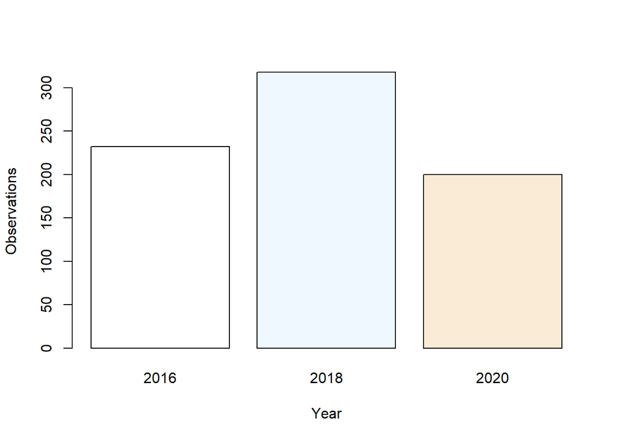

```r
set.seed(105764460)

index <- sample(nrow(finalIowa), 750)

sampleData <- finalIowa[index,]

sampleVolumebyYear <- tapply(sampleData$`Volume Sold (Liters)`, sampleData$Year, median)
sampleBottlesbyYear <- tapply(sampleData$`Bottles Sold`, sampleData$Year, median)
samplePricebyYear <- tapply(sampleData$`Sale (Dollars)`, sampleData$Year, median)
sampleRetailbyYear <- tapply(sampleData$`State Bottle Retail`, sampleData$Year, median)

barplot(table(sampleData$Year), col = colors(), xlab = "Year", ylab = "Observations")
```

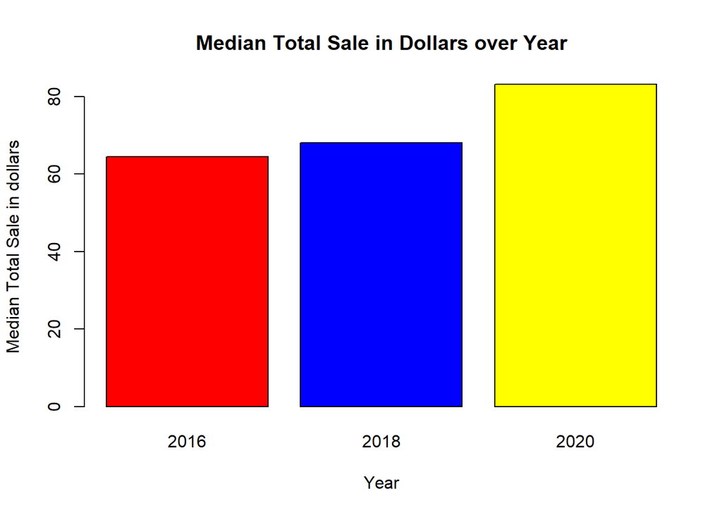

```r
barplot(samplePricebyYear, xlab = "Year", ylab = "Median Total Sale in dollars", col = c("red", "blue", "yellow"), main = "Median Total Sale in Dollars over Year")
```

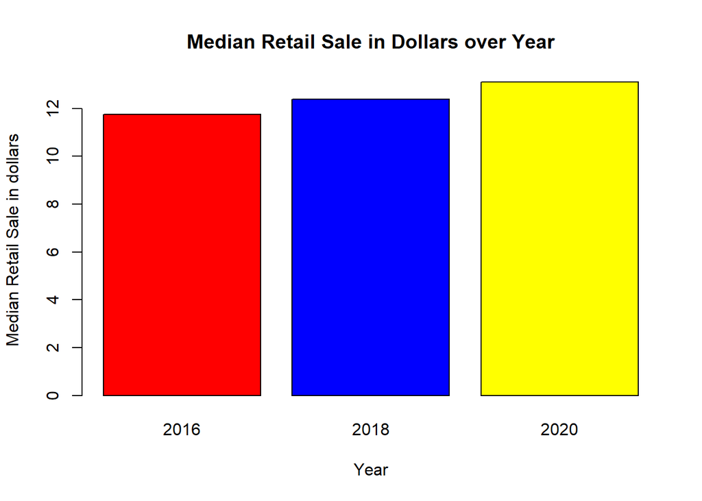

```r
barplot(sampleRetailbyYear, xlab = "Year", ylab = "Median Retail Sale in dollars", col = c("red", "blue", "yellow"), main = "Median Retail Sale in Dollars over Year")
```